# Backprop (1)

## Backpropagation Exercise

In this exercise we will use backpropagation to train a multi-layer perceptron (with a single hidden layer). We will experiment with different patterns and see how quickly or slowly the weights converge. We will see the impact and interplay of different parameters such as learning rate, number of iterations, and number of data points.

```python
#Preliminaries
from __future__ import division, print_function
import numpy as np
import matplotlib.pyplot as plt
%matplotlib inline
```

Fill out the code below so that it creates a multi-layer perceptron with a single hidden layer (with 4 nodes) and trains it via back-propagation. Specifically your code should:

1. Initialize the weights to random values between -1 and 1
2. Perform the feed-forward computation
3. Compute the loss function
4. Calculate the gradients for all the weights via back-propagation
5. Update the weight matrices (using a learning_rate parameter)
6. Execute steps 2-5 for a fixed number of iterations
7. Plot the accuracies and log loss and observe how they change over time

Once your code is running, try it for the different patterns below.

- Which patterns was the neural network able to learn quickly and which took longer?
- What learning rates and numbers of iterations worked well?
- If you have time, try varying the size of the hidden layer and experiment with different activation functions (e.g. ReLu)

```
shape of x_mat_full is (500, 3)
shape of y is (500,)
```

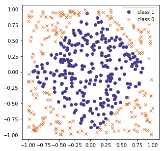

```python
## This code below generates two x values and a y value according to different patterns
## It also creates a "bias" term (a vector of 1s)
## The goal is then to learn the mapping from x to y using a neural network via back-propagation

num_obs = 500
x_mat_1 = np.random.uniform(-1,1,size = (num_obs,2))
x_mat_bias = np.ones((num_obs,1))
x_mat_full = np.concatenate( (x_mat_1,x_mat_bias), axis=1)


# # Diamond Pattern

#below we select all the absolute values at index 0 and 1 in the x_mat_full var and get their boolean representation
#than convert those boolean to integers
y = ((np.abs(x_mat_full[:,0]) + np.abs(x_mat_full[:,1]))<1).astype(int)


#print the shape of the x and y
print('shape of x_mat_full is {}'.format(x_mat_full.shape))
print('shape of y is {}'.format(y.shape))

#map the x values with the y values where y == True we plot a blue dot and where y == False we plot a star in chocolatish type of color
fig, ax = plt.subplots(figsize=(5, 5))
ax.plot(x_mat_full[y==1, 0],x_mat_full[y==1, 1], 'ro', label='class 1', color='darkslateblue')
ax.plot(x_mat_full[y==0, 0],x_mat_full[y==0, 1], 'bx', label='class 0', color='chocolate')
ax.legend(loc='best')
ax.axis('equal');
```

```python
y.shape
```

```
(500,)
```

Here are some helper functions

```python
W_1
```

[output not shown]

```python
def multiplier(arr1, arr2):
    '''this function plays the role of np.dot() multiplication'''

    #get the lenght of array 1
    count = len(arr1)
    # create a array of size lenght of array 1
    product = np.zeros([count])

    #loop through the size of the array or for each row in our arrays
    for i in range(count):

        #we get the product row wise
        product[i] = np.dot(arr1[i], arr2[i])
    return product.reshape(count,1) #and reshape it to 2D array of size (count,1)


def multiplier2(arr1, arr2):
    '''this function and add the '''

    #get the lenght of array 1
    count = len(arr1)
    # create a array of size lenght of array 1
    product = np.zeros([count])

    #loop through the size of the array or for each row in our arrays
    for i in range(count):

        # this time around we get the  product of array 1 row (i) i being the iterator which will change the index as
        # and arra2 row wise of column 0 + row in array2 column 1
        product[i] = (arr1[i] * arr2[i,0]) + arr2[i,1]

    return product.reshape(count,1)
```

```python
def sigmoid(x):
    """
    Sigmoid function
    """
    return 1.0 / (1.0 + np.exp(-x))


def loss_fn(y_true, y_pred, eps=1e-16):
    """
    Loss function we would like to optimize (minimize)
    We are using Logarithmic Loss
    http://scikit-learn.org/stable/modules/model_evaluation.html#log-loss
    """
    y_pred = np.maximum(y_pred,eps)
    y_pred = np.minimum(y_pred,(1-eps))
    return -(np.sum(y_true * np.log(y_pred)) + np.sum((1-y_true)*np.log(1-y_pred)))/len(y_true)


def forward_pass(W1, W2):
    """
    Does a forward computation of the neural network
    Takes the input `x_mat` (global variable) and produces the output `y_pred`
    Also produces the gradient of the log loss function
    """
    global x_mat
    global y
    global num_
    # First, compute the new predictions `y_pred`

    #feed forward NN
    #build our first layer by computing the input and the weight
    z_2 = multiplier(x_mat, W1)

    #pass the product through our activation function ()
    a_2 = sigmoid(z_2) #this is our first hidden layer

    # we use the output of our first hidden layer to build a second hidden layer
    # so second hidden layer is the product of our first hidden layer and w2
    z_3 = multiplier2(a_2, W2)

    #now we pass the ouptput of the second hidden layer through an activaiton function and reshape it to a 1D array
    # will be the output layer and final layer of our NN
    y_pred = sigmoid(z_3).reshape((len(x_mat),))


    # # backpropagation

    # Now compute the gradient

    #we start by computing the error or the difference between our final output and the expected result
    J_z_3_grad = -y + y_pred

    #simply put the final output of the FNN is a guess it doesn't have to be true but we gonna use that to learn the pattern
    #for that we gonna use gradient decent to minimize the error and learn the pattern


    J_W_2_grad = np.dot(J_z_3_grad, a_2)
    a_2_z_2_grad = sigmoid(z_2)*(1-sigmoid(z_2))
    J_W_1_grad = (np.dot((J_z_3_grad).reshape(-1,1), W_2.reshape(-1,1).T)*a_2_z_2_grad).T.dot(x_mat).T
    gradient = (J_W_1_grad, J_W_2_grad)

    # return
    return y_pred, gradient


def plot_loss_accuracy(loss_vals, accuracies):
    fig = plt.figure(figsize=(16, 8))
    fig.suptitle('Log Loss and Accuracy over iterations')

    ax = fig.add_subplot(1, 2, 1)
    ax.plot(loss_vals)
    ax.grid(True)
    ax.set(xlabel='iterations', title='Log Loss')

    ax = fig.add_subplot(1, 2, 2)
    ax.plot(accuracies)
    ax.grid(True)
    ax.set(xlabel='iterations', title='Accuracy');
```

Complete the pseudocode below

```python
x_mat
```

[output not shown]

```
0th interation
Loss =======================  1.0

Accuracy ===================  0.0


200th interation
Loss =======================  6.0

Accuracy ===================  2.0


400th interation
Loss =======================  11.0

Accuracy ===================  25.0


600th interation
Loss =======================  13.0

Accuracy ===================  25.0


800th interation
Loss =======================  14.0

Accuracy ===================  24.0


1000th interation
Loss =======================  14.0

Accuracy ===================  24.0


1200th interation
Loss =======================  16.0

Accuracy ===================  28.0
```

[output cut: 33 more lines]

```
Loss =======================  15.0

Accuracy ===================  49.0


2600th interation
Loss =======================  15.0

Accuracy ===================  49.0


2800th interation
Loss =======================  15.0

Accuracy ===================  49.0
```

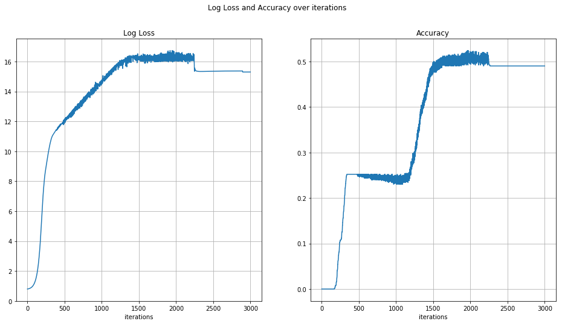

```python
#### Initialize the network parameters

np.random.seed(1241)

#create a array with random number between -1 and 1, our array will the same dimension and same number of rows
random_weights = np.random.uniform(-1,1,size = (num_obs,2)) # To Get random Weights for W_1


bias_factor = np.ones((num_obs,1)) # A placeholder for bias in dot function
#using the array with random number and the above with ones(bias) we put them together and that makes up our first weight
W_1 = np.concatenate( (random_weights,bias_factor), axis=1)

random_weights = np.random.uniform(-1,1,size = (num_obs,1)) # To get random weights for W_2
bias_factor = np.ones((num_obs,1)) # A placeholder for Bias in dot function
#using the array with random number and the above with ones(bias) we put them together and that makes up our second weight
W_2 = np.concatenate( (random_weights,bias_factor), axis=1)

num_iter = 3000
learning_rate = 0.0009
x_mat = x_mat_full

loss_vals, accuracies = [], []
for i in range(num_iter):
    ### Do a forward computation, and get the gradient
    y_pred, gradient = forward_pass(W_1, W_2)
    ## Update the weight matrices
    for weight in range(num_obs):
        W_1[weight, 0] += (gradient[0][0][weight] * learning_rate)
        W_1[weight, 1] += (gradient[0][1][weight] * learning_rate)
        W_2[weight, 0] += (gradient[0][2][weight] * learning_rate)
    ### Compute the loss and accuracy
    loss = loss_fn(y, y_pred)
    # Calculate the accuracy between y and y_pred
    bool_arr = y == y_pred
    correct = np.sum(bool_arr)
    accuracy = correct / num_obs
    # Add the values to the lists
    loss_vals.append(loss)
    accuracies.append(accuracy)
    ## Print the loss and accuracy for every 200th iteration
    if i % 200 == 0:
        print(f"{i}th interation")
        print('Loss ======================= ', round(loss), '\n\nAccuracy =================== ', round(accuracy*100),'\n\n')

plot_loss_accuracy(loss_vals, accuracies)
```

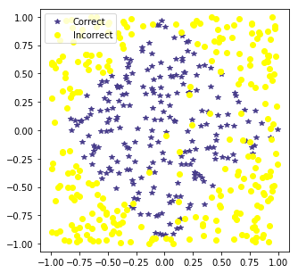

```python
#### Plot the predicted answers with mistakes in yellow

#compare the predicted and expected values and get their boolean results
bool_arr = y == y_pred

#set the figure and and axes
fig, ax = plt.subplots(figsize=(5, 5))


#plot the true boolean from the above comparison in blue
ax.plot(x_mat_full[bool_arr == True, 0], x_mat_full[bool_arr == True, 1], '*', label='Correct', color='darkslateblue')

#and so we do the with the mistake in yellow

ax.plot(x_mat_full[bool_arr == False, 0], x_mat_full[bool_arr == False, 1], 'o', label='Incorrect', color='yellow')
ax.legend(loc='best')
ax.axis('equal');
```